# Marketing Analytics Project: Black Friday

Weicheng Zhang, Zilei Zhang, Maura Oray, Gloria Zheng

### 1. Introduction

**Objective:**  
* Look at the distribution of customer demographics

- Determine which variables are highly correlated with purchase
- Identify which products are high-selling

The dataset comes from a competition hosted by Analytics Vidhya.

Group Github url: https://github.com/MauraO/Marketing-Analytics-Project

```r
#Load libraries
library(VIM)
library(readr)
library(tidyverse)
library(dplyr)
library(ggthemes)
library(devtools)
devtools::install_github('cttobin/ggthemr')
library(ggthemr)

BF <- read_csv("BlackFriday.csv")
```

### 2. Data Description

**a. Describe the conceptual measure types of the different variables**

- User_ID: discrete, nominal
- Product_ID: discrete, nominal
- Gender: discrete, nominal
- Age: discrete, ordinal
- Occupation: discrete, nominal
- City_Category: discrete, nominal
- Stay_in_Current_City_Years: continuous, ratio
- Marital_Status: discrete, nominal
- Product_Category_1: discrete, nominal
- Product_Category_2: discrete, nominal
- Product_Category_3: discrete, nominal
- Purchase: continuous, ratio

**b. Mention all the steps you took to clean the data** * Step 1. Check if the data contains missing values

```r
sum(complete.cases(BF))
```

```
## [1] 164278
```

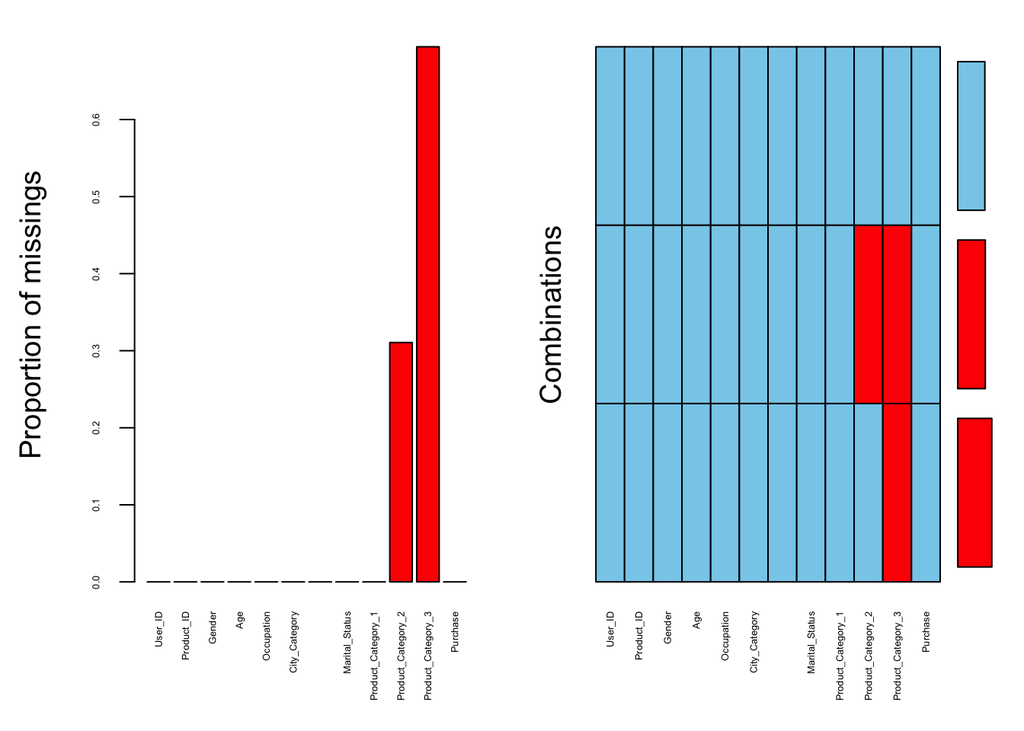

```r
aggr(BF,cex.axis = .4) #164,278 NA values
```

```r
BF$Product_Category_2[is.na(BF$Product_Category_2)]<- 0 #0 - means the category_2 is missing
BF$Product_Category_3[is.na(BF$Product_Category_3)]<- 0 #0 - means the category_3 is missing
```

In the above visualization, we wanted to see which variables had the most NA values. We saw that the NA values were only concentrated in Product Category 2 and Product Category 3.

- Step 2. Check the structure of the data

```r
summary(BF)
```

```
##     User_ID         Product_ID           Gender
##  Min.   :1000001   Length:537577      Length:537577
##  1st Qu.:1001495   Class :character   Class :character
##  Median :1003031   Mode  :character   Mode  :character
##  Mean   :1002992
##  3rd Qu.:1004417
##  Max.   :1006040
##      Age              Occupation     City_Category
##  Length:537577      Min.   : 0.000   Length:537577
##  Class :character   1st Qu.: 2.000   Class :character
##  Mode  :character   Median : 7.000   Mode  :character
##                     Mean   : 8.083
##                     3rd Qu.:14.000
##                     Max.   :20.000
##  Stay_In_Current_City_Years Marital_Status   Product_Category_1
##  Length:537577              Min.   :0.0000   Min.   : 1.000
##  Class :character           1st Qu.:0.0000   1st Qu.: 1.000
##  Mode  :character           Median :0.0000   Median : 5.000
##                             Mean   :0.4088   Mean   : 5.296
##                             3rd Qu.:1.0000   3rd Qu.: 8.000
##                             Max.   :1.0000   Max.   :18.000
##  Product_Category_2 Product_Category_3    Purchase
##  Min.   : 0.000     Min.   : 0.000     Min.   :  185
##  1st Qu.: 0.000     1st Qu.: 0.000     1st Qu.: 5866
##  Median : 5.000     Median : 0.000     Median : 8062
##  Mean   : 6.785     Mean   : 3.872     Mean   : 9334
##  3rd Qu.:14.000     3rd Qu.: 8.000     3rd Qu.:12073
##  Max.   :18.000     Max.   :18.000     Max.   :23961
```

```r
str(BF)
```

```
## Classes 'tbl_df', 'tbl' and 'data.frame':    537577 obs. of  12 variables:
##  $ User_ID                   : int  1000001 1000001 1000001 1000001 1000002 1000003 1000004 1000004 1000004 1000005 ...
##  $ Product_ID                : chr  "P00069042" "P00248942" "P00087842" "P00085442" ...
##  $ Gender                    : chr  "F" "F" "F" "F" ...
##  $ Age                       : chr  "0-17" "0-17" "0-17" "0-17" ...
##  $ Occupation                : int  10 10 10 10 16 15 7 7 7 20 ...
##  $ City_Category             : chr  "A" "A" "A" "A" ...
##  $ Stay_In_Current_City_Years: chr  "2" "2" "2" "2" ...
##  $ Marital_Status            : int  0 0 0 0 0 0 1 1 1 1 ...
##  $ Product_Category_1        : int  3 1 12 12 8 1 1 1 1 8 ...
##  $ Product_Category_2        : num  0 6 0 14 0 2 8 15 16 0 ...
##  $ Product_Category_3        : num  0 14 0 0 0 0 17 0 0 0 ...
##  $ Purchase                  : int  8370 15200 1422 1057 7969 15227 19215 15854 15686 7871 ...
##  - attr(*, "spec")=List of 2
##   ..$ cols   :List of 12
##   .. ..$ User_ID                   : list()
##   .. .. ..- attr(*, "class")= chr  "collector_integer" "collector"
##   .. ..$ Product_ID                : list()
##   .. .. ..- attr(*, "class")= chr  "collector_character" "collector"
##   .. ..$ Gender                    : list()
##   .. .. ..- attr(*, "class")= chr  "collector_character" "collector"
##   .. ..$ Age                       : list()
##   .. .. ..- attr(*, "class")= chr  "collector_character" "collector"
##   .. ..$ Occupation                : list()
##   .. .. ..- attr(*, "class")= chr  "collector_integer" "collector"
##   .. ..$ City_Category             : list()
##   .. .. ..- attr(*, "class")= chr  "collector_character" "collector"
##   .. ..$ Stay_In_Current_City_Years: list()
##   .. .. ..- attr(*, "class")= chr  "collector_character" "collector"
##   .. ..$ Marital_Status            : list()
##   .. .. ..- attr(*, "class")= chr  "collector_integer" "collector"
##   .. ..$ Product_Category_1        : list()
##   .. .. ..- attr(*, "class")= chr  "collector_integer" "collector"
##   .. ..$ Product_Category_2        : list()
##   .. .. ..- attr(*, "class")= chr  "collector_integer" "collector"
##   .. ..$ Product_Category_3        : list()
##   .. .. ..- attr(*, "class")= chr  "collector_integer" "collector"
##   .. ..$ Purchase                  : list()
##   .. .. ..- attr(*, "class")= chr  "collector_integer" "collector"
##   ..$ default: list()
##   .. ..- attr(*, "class")= chr  "collector_guess" "collector"
##   ..- attr(*, "class")= chr "col_spec"
```

- Step 3. Type coercion

```r
BF[1:11] = lapply(BF[1:11], factor)
```

The majority of the variables were either integers or characters. We decided to coerce the variables into factors (all except purchase) because the majority of them are categorical.

- Step 4. Tidy the data

```r
#Demographic data
demo = BF %>%
  select(-starts_with("Product")) %>%
  group_by(User_ID) %>%
  mutate(Purchase = sum(Purchase))

#5891 unique customers

demo = demo[!duplicated(demo$User_ID), ]
```

### 3. Summary statistics and Data Visualizations

> **Customer Demographics**  
> * Table 1. The distribution of Gender and Maritial Status

```r
# Two way frequency table showing different combination of customers using gender and marital status
customer = table(demo$Gender, demo$Marital_Status)
colnames(customer) = c("Unmarried", "Married")
rownames(customer) = c("Female", "Male")

addmargins(customer)
```

```
##
##          Unmarried Married  Sum
##   Female       947     719 1666
##   Male        2470    1755 4225
##   Sum         3417    2474 5891
```

```r
addmargins(prop.table(customer))
```

```
##
##          Unmarried   Married       Sum
##   Female 0.1607537 0.1220506 0.2828043
##   Male   0.4192837 0.2979121 0.7171957
##   Sum    0.5800373 0.4199627 1.0000000
```

The two-way frequency table shows 4 combinations of customers. There are 5891 distinct customers in total, and 2470 of them are unmarried males; 1755 are married males; 947 are unmarried females; 719 are married females.  
In this two-way frequency table, we can deduce that there are more unmarried customers (58%) than married (42%) and more male customers (72%) than female (28%). Therefore, in the following analyses regarding gender and marital status, we will focus on customers’ average purchase amount instead of the sum purchase, because the sum purchase will easily be influenced by the number of people, which may cause a biased conclusion.

- Plot 1. Distribution of Purchase

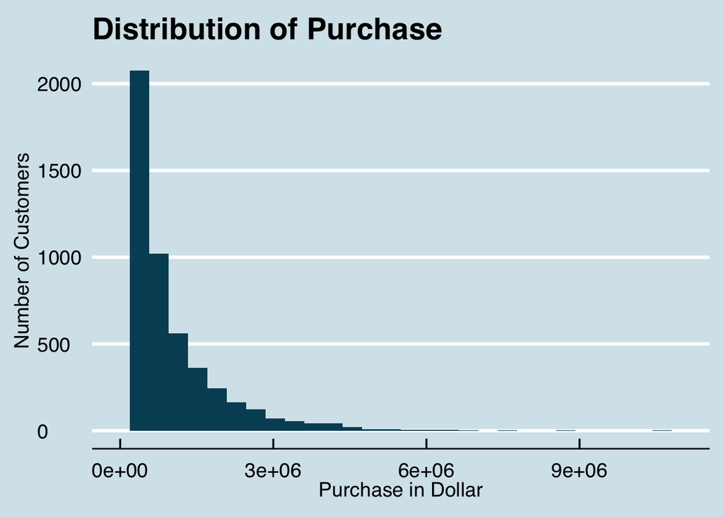

```r
demo %>%
  ggplot(aes(Purchase)) +
  geom_histogram(fill = "#014d64") +
  scale_x_continuous(limits = c(0, 11000000)) +
  theme_economist(base_size=14)+
  scale_fill_economist()+
  labs(x = "Purchase in Dollar", y = "Number of Customers", title = "Distribution of Purchase")
```

- Plot 2. Purchase Distribution by Gender and City

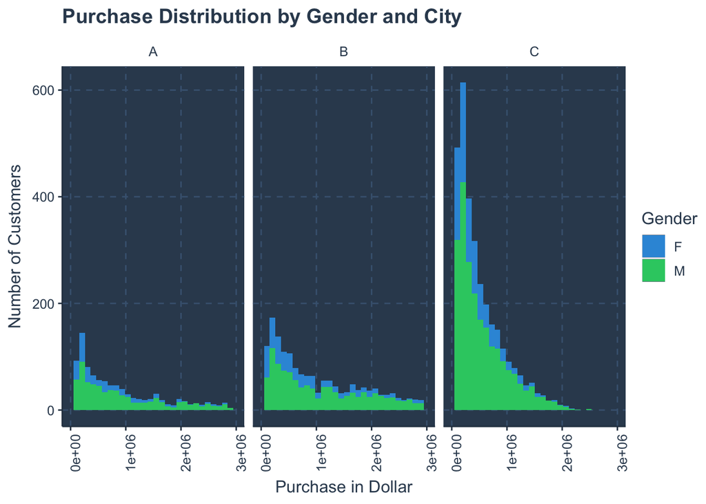

```r
ggthemr('flat dark')
demo %>%
  ggplot(aes(x = Purchase, fill = Gender)) +
  geom_histogram() +
  facet_wrap(~City_Category) +
  scale_x_continuous(limits = c(0, 3000000)) +
  labs(x = "Purchase in Dollar", y = "Number of Customers", title = "Purchase Distribution by Gender and City")+
  theme(axis.text.x = element_text(angle = 90, hjust = 0.5))
```

- Plot 3. Purchase Distribution by Occupation

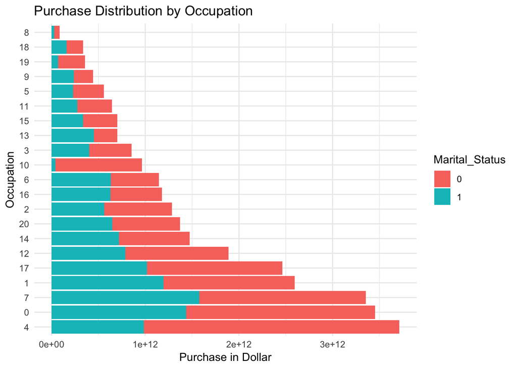

```r
ggthemr_reset()
demo %>%
  group_by(Occupation)%>%
  ggplot(aes(x = fct_infreq(Occupation), y = sum(Purchase), fill = Marital_Status)) +
  geom_bar(stat = "identity") +
  theme_minimal() +
  coord_flip() +
  labs(x = "Occupation", y = "Purchase in Dollar", title = "Purchase Distribution by Occupation")
```

- Plot 4. Purchase Distribution by Age

```r
ggthemr('sky')
```

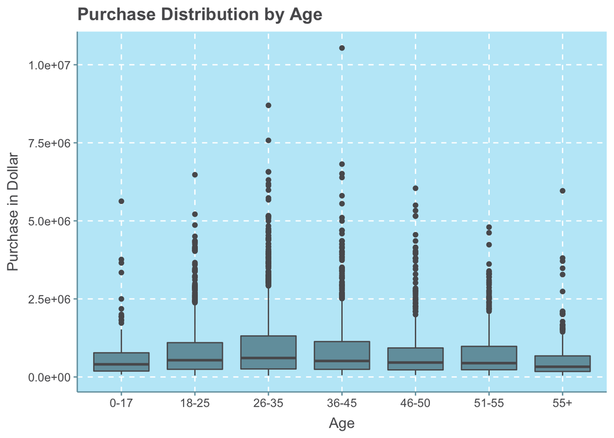

```r
demo %>%
  ggplot(aes(x = Age, y = Purchase)) +
  geom_boxplot() +
  labs(x = "Age", y = "Purchase in Dollar", title = "Purchase Distribution by Age")
```

- Plot 5. Purchase distribution by Gender

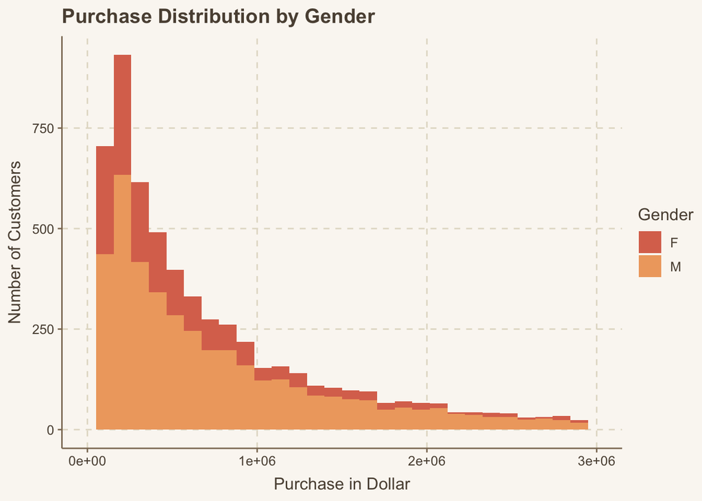

```r
ggthemr('dust',type = "outer")
demo %>%
  ggplot(aes(x = Purchase, fill = Gender)) +
  geom_histogram()+
  scale_x_continuous(limits = c(0, 3000000)) +
  labs(x = "Purchase in Dollar", y = "Number of Customers", title = "Purchase Distribution by Gender")
```

- Plot 6. Purchase distribution by stay in city years

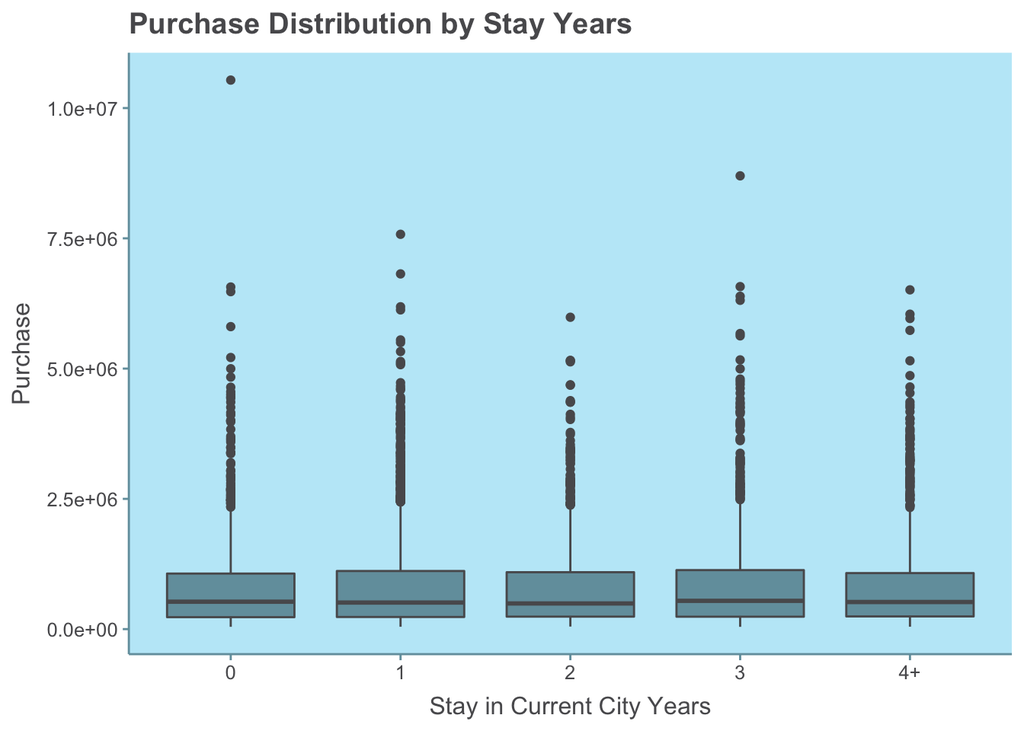

```r
ggthemr('sky', layout = 'minimal')
demo %>%
  ggplot(aes(x = Stay_In_Current_City_Years, y = Purchase)) +
  geom_boxplot()+
  labs(x = "Stay in Current City Years", y = "Purchase", title = "Purchase Distribution by Stay Years")
```

- Plot 7. The most popular product category The product category 1 has three of the most popular products: 5, 1 and 8

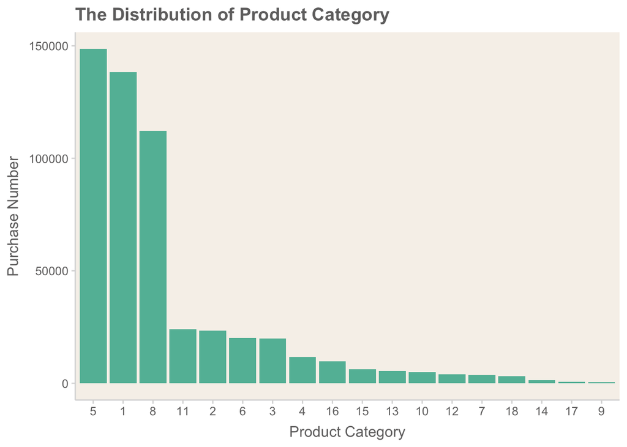

```r
ggthemr('light', layout = 'clean')
BF_prt = BF %>%
  group_by(Product_ID) %>%
  mutate(sumpp = sum(Purchase), avgpp = mean(Purchase))
BF_prt = BF_prt[-c(3:8)]
BF_prt%>%
  ggplot(aes(x = Product_Category_1))+
  geom_bar(aes(x = fct_infreq(as.factor(Product_Category_1))))+
  labs(x ="Product Category" , y = "Purchase Number", title = "The Distribution of Product Category")
```

### 4. Preliminary statistical analyses

**Do men spend more money on Black Friday than women?**

```r
#Independent t-test
t.test(demo[demo$Gender == "M", ]$Purchase,
       demo[demo$Gender == "F", ]$Purchase,
       paired = FALSE,
       alternative = "greater")
```

```
##
##  Welch Two Sample t-test
##
## data:  demo[demo$Gender == "M", ]$Purchase and demo[demo$Gender == "F", ]$Purchase
## t = 8.6542, df = 3709.2, p-value < 2.2e-16
## alternative hypothesis: true difference in means is greater than 0
## 95 percent confidence interval:
##  172432.4      Inf
## sample estimates:
## mean of x mean of y
##  911963.2  699054.0
```

Because we want to figure out whether the gender influence the purchase. In table 1 and plot 2, we find that there are more male than female and male have more purchase than female. Therefore, we want to use an independent t-test to test whether it is significant.  
Based on the evidence from this data set and the result from t-test(p-value < 2.2e-16), we think the probability that male have same mean purchase as female is less than 5%, and the probability that male have larger mean purchase than female is bigger than 95%. Therefore, we reject the null hypothesis: the male have the same mean purchase as female, and accept the alternative hypothesis: Male have larger mean purchase than female. Moreover, from the sample, we can get the estimated mean purchase of male and female: 911963.2 and 699054.0

**Do unmarried customers spend more money on Black Friday than married?**

```r
#Independent t-test
t.test(demo[demo$Marital_Status == 0, ]$Purchase,
       demo[demo$Marital_Status == 1, ]$Purchase,
       paired = FALSE,
       alternative = "greater")
```

```
##
##  Welch Two Sample t-test
##
## data:  demo[demo$Marital_Status == 0, ]$Purchase and demo[demo$Marital_Status == 1, ]$Purchase
## t = 1.5859, df = 5392.3, p-value = 0.05641
## alternative hypothesis: true difference in means is greater than 0
## 95 percent confidence interval:
##  -1454.306       Inf
## sample estimates:
## mean of x mean of y
##  868097.6  829175.0
```

Because we want to figure out whether the maritial status influence the purchase. In table 1 and plot 3, we find that there are more unmarritial people than maritial people and unmaritial customers seem to have more purchase than maritial customers. Therefore, we want to use an independent t-test to test whether it is significant.  
Based on the evidence from this data set and the result from t-test(p-value = 0.056), we think the probability that unmaritial customers have same mean purchase as maritial customers is bigger than 5% but less than 10% , and the probability that unmaritial customers have larger mean purchase than maritial customers is less than 95% but bigger than 90%. Therefore, in 95% confidential level, we can not reject the null hypothesis: the unmatitial customers have the same mean purchase as maritial customers, but in 90% confidential level, we can reject it and accept the alternative hypothesis: unmaritial customers have larger mean purchase than maritial customers.

```r
# Chi square test
# Creat purchase category
A1 = quantile(demo$Purchase, c(0.33,0.66))
A1
```

```
##      33%      66%
## 304987.6 826809.6
```

```r
demo = demo %>%
  mutate(purchase_category = cut(Purchase, breaks = c(-Inf, 304987.6, 826809.6, Inf),
  labels = c("City A", "City B", "City C")))

# Creat two way frequency table
table(demo$City_Category, demo$purchase_category)
```

```
##
##     City A City B City C
##   A    276    287    482
##   B    360    460    887
##   C   1308   1197    634
```

```r
# Apply chi square test
chisq.test(table(demo$Age, demo$purchase_category))
```

```
##
##  Pearson's Chi-squared test
##
## data:  table(demo$Age, demo$purchase_category)
## X-squared = 102.05, df = 12, p-value < 2.2e-16
```